# New Insights on Poverty

January 29, 2016

# Introduction

This lab is based Hans Rosling talks [New Insights on Poverty](https://www.ted.com/talks/hans_rosling_reveals_new_insights_on_poverty?language=en) and [The Best Stats You’ve Ever Seen](https://www.ted.com/talks/hans_rosling_shows_the_best_stats_you_ve_ever_seen).

1. Sri Lanka or Turkey
2. Poland or South Korea
3. Malaysia or Russia
4. Pakistan or Vietnam
5. Thailand or South Africa

Now let’s use data to answer the questions. There are a number of datasets available on the website. You can visit the website and browse the datasets to find this one.

```r
library(dplyr)
library(readr)
child_mortality <-read_csv("http://spreadsheets.google.com/pub?key=0ArfEDsV3bBwCcGhBd2NOQVZ1eWowNVpSNjl1c3lRSWc&output=csv")
```

By printing `dat`

```
## Source: local data frame [275 x 217]
##
##     Under five mortality   1800   1801   1802   1803   1804   1805   1806
##                    (chr)  (dbl)  (dbl)  (dbl)  (dbl)  (dbl)  (dbl)  (dbl)
## 1               Abkhazia     NA     NA     NA     NA     NA     NA     NA
## 2            Afghanistan 468.58 468.58 468.58 468.58 468.58 468.58 469.98
## 3  Akrotiri and Dhekelia     NA     NA     NA     NA     NA     NA     NA
## 4                Albania 375.20 375.20 375.20 375.20 375.20 375.20 375.20
## 5                Algeria 460.21 460.21 460.21 460.21 460.21 460.21 460.21
## 6         American Samoa     NA     NA     NA     NA     NA     NA     NA
## 7                Andorra     NA     NA     NA     NA     NA     NA     NA
## 8                 Angola 485.68 485.68 485.68 485.68 485.68 485.68 485.68
## 9               Anguilla     NA     NA     NA     NA     NA     NA     NA
## 10   Antigua and Barbuda 473.60 469.77 465.97 462.20 458.47 454.76 451.08
## ..                   ...    ...    ...    ...    ...    ...    ...    ...
## Variables not shown: 1807 (dbl), 1808 (dbl), 1809 (dbl), 1810 (dbl), 1811
##   (dbl), 1812 (dbl), 1813 (dbl), 1814 (dbl), 1815 (dbl), 1816 (dbl), 1817
##   (dbl), 1818 (dbl), 1819 (dbl), 1820 (dbl), 1821 (dbl), 1822 (dbl), 1823
##   (dbl), 1824 (dbl), 1825 (dbl), 1826 (dbl), 1827 (dbl), 1828 (dbl), 1829
##   (dbl), 1830 (dbl), 1831 (dbl), 1832 (dbl), 1833 (dbl), 1834 (dbl), 1835
##   (dbl), 1836 (dbl), 1837 (dbl), 1838 (dbl), 1839 (dbl), 1840 (dbl), 1841
##   (dbl), 1842 (dbl), 1843 (dbl), 1844 (dbl), 1845 (dbl), 1846 (dbl), 1847
##   (dbl), 1848 (dbl), 1849 (dbl), 1850 (dbl), 1851 (dbl), 1852 (dbl), 1853
##   (dbl), 1854 (dbl), 1855 (dbl), 1856 (dbl), 1857 (dbl), 1858 (dbl), 1859
##   (dbl), 1860 (dbl), 1861 (dbl), 1862 (dbl), 1863 (dbl), 1864 (dbl), 1865
##   (dbl), 1866 (dbl), 1867 (dbl), 1868 (dbl), 1869 (dbl), 1870 (dbl), 1871
##   (dbl), 1872 (dbl), 1873 (dbl), 1874 (dbl), 1875 (dbl), 1876 (dbl), 1877
##   (dbl), 1878 (dbl), 1879 (dbl), 1880 (dbl), 1881 (dbl), 1882 (dbl), 1883
##   (dbl), 1884 (dbl), 1885 (dbl), 1886 (dbl), 1887 (dbl), 1888 (dbl), 1889
##   (dbl), 1890 (dbl), 1891 (dbl), 1892 (dbl), 1893 (dbl), 1894 (dbl), 1895
##   (dbl), 1896 (dbl), 1897 (dbl), 1898 (dbl), 1899 (dbl), 1900 (dbl), 1901
##   (dbl), 1902 (dbl), 1903 (dbl), 1904 (dbl), 1905 (dbl), 1906 (dbl), 1907
##   (dbl), 1908 (dbl), 1909 (dbl), 1910 (dbl), 1911 (dbl), 1912 (dbl), 1913
##   (dbl), 1914 (dbl), 1915 (dbl), 1916 (dbl), 1917 (dbl), 1918 (dbl), 1919
##   (dbl), 1920 (dbl), 1921 (dbl), 1922 (dbl), 1923 (dbl), 1924 (dbl), 1925
##   (dbl), 1926 (dbl), 1927 (dbl), 1928 (dbl), 1929 (dbl), 1930 (dbl), 1931
##   (dbl), 1932 (dbl), 1933 (dbl), 1934 (dbl), 1935 (dbl), 1936 (dbl), 1937
##   (dbl), 1938 (dbl), 1939 (dbl), 1940 (dbl), 1941 (dbl), 1942 (dbl), 1943
##   (dbl), 1944 (dbl), 1945 (dbl), 1946 (dbl), 1947 (dbl), 1948 (dbl), 1949
##   (dbl), 1950 (dbl), 1951 (dbl), 1952 (dbl), 1953 (dbl), 1954 (dbl), 1955
##   (dbl), 1956 (dbl), 1957 (dbl), 1958 (dbl), 1959 (dbl), 1960 (dbl), 1961
##   (dbl), 1962 (dbl), 1963 (dbl), 1964 (dbl), 1965 (dbl), 1966 (dbl), 1967
##   (dbl), 1968 (dbl), 1969 (dbl), 1970 (dbl), 1971 (dbl), 1972 (dbl), 1973
##   (dbl), 1974 (dbl), 1975 (dbl), 1976 (dbl), 1977 (dbl), 1978 (dbl), 1979
##   (dbl), 1980 (dbl), 1981 (dbl), 1982 (dbl), 1983 (dbl), 1984 (dbl), 1985
##   (dbl), 1986 (dbl), 1987 (dbl), 1988 (dbl), 1989 (dbl), 1990 (dbl), 1991
##   (dbl), 1992 (dbl), 1993 (dbl), 1994 (dbl), 1995 (dbl), 1996 (dbl), 1997
##   (dbl), 1998 (dbl), 1999 (dbl), 2000 (dbl), 2001 (dbl), 2002 (dbl), 2003
##   (dbl), 2004 (dbl), 2005 (dbl), 2006 (dbl), 2007 (dbl), 2008 (dbl), 2009
##   (dbl), 2010 (dbl), 2011 (dbl), 2012 (dbl), 2013 (dbl), 2014 (dbl), 2015
##   (dbl)
```

we see that years are represented by columns and we can get these values for our countries using the following code:

```r
countries <- c("Sri Lanka","Turkey", "Poland", "South Korea", "Malaysia", "Russia","Pakistan","Vietnam","Thailand","South Africa")

rename(child_mortality, country=`Under five mortality`) %>%
slice(match(countries,country)) %>% select(country,`2015`)
```

```
## Source: local data frame [10 x 2]
##
##         country  2015
##           (chr) (dbl)
## 1     Sri Lanka   8.7
## 2        Turkey  13.5
## 3        Poland   5.2
## 4   South Korea   3.5
## 5      Malaysia   8.2
## 6        Russia   9.6
## 7      Pakistan  81.1
## 8       Vietnam  21.7
## 9      Thailand  12.3
## 10 South Africa  42.1
```

From here we see that Turkey has a higher rate than Turkey, Poland higher than South Korea, Russia higher than Malaysia, Pakistan much higher than Vietnam and South Africa much higher than Thailand.

Most people get these wrong. Why is this? In part it is due to our preconceived notion that the world is divided into two groups: Western world versus the third world characterized by long life in a small family and short life in a large family respectively. Does the data support this view of two groups?

The necessary data to answer this question is also available from gapminder:

```r
life_expectancy  <- read_csv("http://spreadsheets.google.com/pub?key=phAwcNAVuyj2tPLxKvvnNPA&output=csv")
total_fertility  <- read_csv("http://spreadsheets.google.com/pub?key=phAwcNAVuyj0TAlJeCEzcGQ&output=csv")
```

We want to plot one variable versus the other. However we need to assure that we match the data correctly. To do this we will use the `tidyr` package.

# Tidying data

Before we get started, note that the first column of all three datasets are incorrectly labeled. We fix this right away:

```r
names(child_mortality)[1] <- names(life_expectancy)[1] <- names(total_fertility)[1] <- "country"
```

Now we want each country/year combination to be a unit. We achieve this by using the `gather` function:

```r
library(tidyr)
child_mortality <- child_mortality %>%
  gather(key = year, value = child_mortality,
         2:ncol(child_mortality), -country, convert=TRUE)
life_expectancy <- life_expectancy %>%
  gather(key = year, value = life_expectancy,
         2:ncol(life_expectancy), -country, convert=TRUE)
total_fertility <- total_fertility %>%
  gather(key = year, value = total_fertility,
         2:ncol(total_fertility), -country, convert=TRUE)
```

Now we can join any two columns

```r
dat <- full_join(total_fertility,life_expectancy,
                 by = c("country","year"))
```

We also want to add the continent for each country. We upload a country to continent map we created.

```r
map <- read_delim(file.path("data","continent-info.tsv"),
                  col_names=FALSE,delim ="\t")
continents <- map[[2]][match(dat$country, map[[1]])]
dat <- mutate(dat, continent = continents)
```

We also want to annotate which countries are OECD.

```r
oecd_countries <- readRDS(file.path("data","oecd-countries.rds"))
dat <- mutate(dat, OECD = tolower(country) %in% oecd_countries)
```

Now let’s examine these two variables for 1962

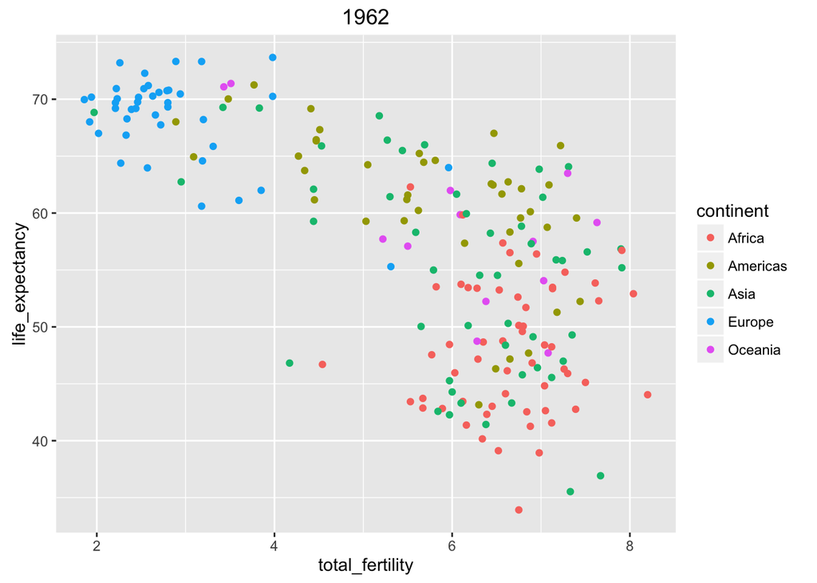

```r
library(ggplot2)
p <- ggplot( filter(dat, year==1962) ,
             aes(total_fertility, life_expectancy) )
p + geom_point( aes(color = continent)) + ggtitle("1962")
```

This data does seems to support a western world (Europe) versus the third world (Africa, Asia and South America) divdie characterized by long life in a small family and short life in a large family respectively. We can highlight the two groups:

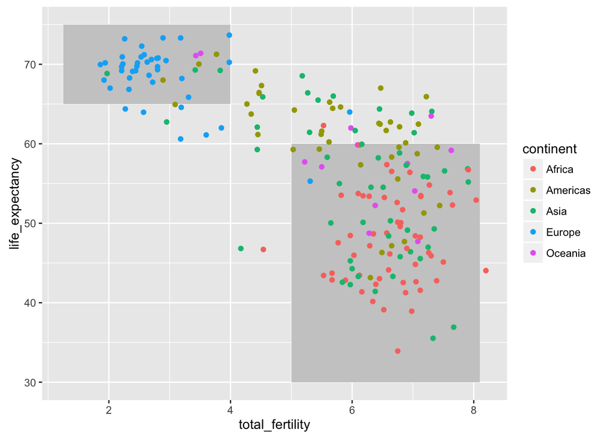

```r
p + geom_rect(aes(xmin=1.25,xmax=4,ymin=65,ymax=75),
              fill="grey80", alpha=0.8) +
    geom_rect(aes(xmin=5,xmax=8.1,ymin=30,ymax=60),
              fill="grey80", alpha=0.8)+
    geom_point( aes(color = continent))
```

However, this was in 1962. Is it still the case?

```r
years <- seq(1962,2012,10)
p <- ggplot( filter(dat, year%in%years) ,
             aes(total_fertility, life_expectancy) ) + facet_wrap(~year) + geom_point( aes(color = continent))
```